# :::About This Project:::

For this project, i wll act as a data analyst for the National Park Service.

i wll be helping them analyze data on endangered species from several different parks.

The National Parks Service would like to perform some data analysis on the conservation statuses of these species and to investigate if there are any patterns or themes to the types of species that become endangered. During this project,i will analyze, clean up, and plot data, pose questions and seek to answer them in a meaningful way.

After i perform analysis, i wll be creating a presentation to share my findings with the National Park Service

# :::Step one::: Gather the data:::

```python
#import library
import pandas as pd
import numpy as np
import matplotlib.pyplot as plt
from scipy.stats import chi2_contingency
```

```python
#import the data set
df=pd.read_csv('E:/my_work_my_work/data analysis project/Biodiversity in National Parks/species_info.csv')
```

```python
#show the data
df.head(6)
```

|  | category | scientific_name | common_names | conservation_status |
| --- | --- | --- | --- | --- |
| 0 | Mammal | Clethrionomys gapperi gapperi | Gapper's Red-Backed Vole | NaN |
| 1 | Mammal | Bos bison | American Bison, Bison | NaN |
| 2 | Mammal | Bos taurus | Aurochs, Aurochs, Domestic Cattle (Feral), Dom... | NaN |
| 3 | Mammal | Ovis aries | Domestic Sheep, Mouflon, Red Sheep, Sheep (Feral) | NaN |
| 4 | Mammal | Cervus elaphus | Wapiti Or Elk | NaN |
| 5 | Mammal | Odocoileus virginianus | White-Tailed Deer | NaN |

# Step two:::assess the data

```python
df.info()
```

```
<class 'pandas.core.frame.DataFrame'>
RangeIndex: 5824 entries, 0 to 5823
Data columns (total 4 columns):
category               5824 non-null object
scientific_name        5824 non-null object
common_names           5824 non-null object
conservation_status    191 non-null object
dtypes: object(4)
memory usage: 182.1+ KB
```

```python
df.dtypes
```

```
category               object
scientific_name        object
common_names           object
conservation_status    object
dtype: object
```

```python
df.shape
```

```
(5824, 4)
```

```python
#How many different species are in the species DataFrame
number_of_species=df.scientific_name.nunique()
number_of_species
```

```
5541
```

```python
#What are the different values of category in the DataFrame species
types_of_category=df.category.unique()
types_of_category
```

```
array(['Mammal', 'Bird', 'Reptile', 'Amphibian', 'Fish', 'Vascular Plant',
       'Nonvascular Plant'], dtype=object)
```

```python
#What are the different values of conservation_status
diff_values_of_conservation_status=df.conservation_status.unique()
diff_values_of_conservation_status
```

```
array([nan, 'Species of Concern', 'Endangered', 'Threatened', 'In Recovery'], dtype=object)
```

```python
# count how many scientific_name falls into each conservation_status criteria
conservation_count=df.groupby('conservation_status').scientific_name.nunique().reset_index()
```

```python
conservation_count
```

|  | conservation_status | scientific_name |
| --- | --- | --- |
| 0 | Endangered | 15 |
| 1 | In Recovery | 4 |
| 2 | Species of Concern | 151 |
| 3 | Threatened | 10 |

# Step three:::clean the data

*replace NaN in conservation_status column with 'No Intervention'*

```python
#code
df.conservation_status.fillna('No Intervention',inplace=True)
```

```python
#test
conservation_count_fixed=df.groupby('conservation_status').scientific_name.nunique().reset_index()
conservation_count_fixed
```

|  | conservation_status | scientific_name |
| --- | --- | --- |
| 0 | Endangered | 15 |
| 1 | In Recovery | 4 |
| 2 | No Intervention | 5363 |
| 3 | Species of Concern | 151 |
| 4 | Threatened | 10 |

# Step four:::perform EDA

*Plotting Conservation Status by Species*

```python
protection_counts = df.groupby('conservation_status').scientific_name.nunique()\
.reset_index().sort_values(by='scientific_name')
```

```python
protection_counts
```

|  | conservation_status | scientific_name |
| --- | --- | --- |
| 1 | In Recovery | 4 |
| 4 | Threatened | 10 |
| 0 | Endangered | 15 |
| 3 | Species of Concern | 151 |
| 2 | No Intervention | 5363 |

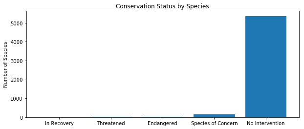

```python
plt.figure(figsize=(10, 4))
ax = plt.subplot()
plt.bar(range(len(protection_counts)),protection_counts.scientific_name.values)
ax.set_xticks(range(len(protection_counts)))
ax.set_xticklabels(protection_counts.conservation_status.values)
plt.ylabel('Number of Species')
plt.title('Conservation Status by Species')
labels = [e.get_text() for e in ax.get_xticklabels()]
plt.show()
```

# Investigating Endangered Species

*Are certain types of species more likely to be endangered?*

```python
#Create a new column in species called is_protected, which is True if conservation_status
#is not equal to 'No Intervention', and False otherwise.

df['is_protected']=df.conservation_status!='No Intervention'
#test
df.head(6)
```

|  | category | scientific_name | common_names | conservation_status | is_protected |
| --- | --- | --- | --- | --- | --- |
| 0 | Mammal | Clethrionomys gapperi gapperi | Gapper's Red-Backed Vole | No Intervention | False |
| 1 | Mammal | Bos bison | American Bison, Bison | No Intervention | False |
| 2 | Mammal | Bos taurus | Aurochs, Aurochs, Domestic Cattle (Feral), Dom... | No Intervention | False |
| 3 | Mammal | Ovis aries | Domestic Sheep, Mouflon, Red Sheep, Sheep (Feral) | No Intervention | False |
| 4 | Mammal | Cervus elaphus | Wapiti Or Elk | No Intervention | False |
| 5 | Mammal | Odocoileus virginianus | White-Tailed Deer | No Intervention | False |

```python
#Group the species data frame by the category and is_protected columns and
#count the unique scientific_names in each grouping
category_counts=df.groupby(['category','is_protected']).scientific_name.nunique().reset_index()
```

```python
#test
category_counts
```

|  | category | is_protected | scientific_name |
| --- | --- | --- | --- |
| 0 | Amphibian | False | 72 |
| 1 | Amphibian | True | 7 |
| 2 | Bird | False | 413 |
| 3 | Bird | True | 75 |
| 4 | Fish | False | 115 |
| 5 | Fish | True | 11 |
| 6 | Mammal | False | 146 |
| 7 | Mammal | True | 30 |
| 8 | Nonvascular Plant | False | 328 |
| 9 | Nonvascular Plant | True | 5 |
| 10 | Reptile | False | 73 |
| 11 | Reptile | True | 5 |
| 12 | Vascular Plant | False | 4216 |
| 13 | Vascular Plant | True | 46 |

```python
#create category_counts as a pivot table
category_pivot = category_counts.pivot(columns='is_protected', index='category', values='scientific_name').reset_index()
```

```python
category_pivot
```

| is_protected | category | False | True |
| --- | --- | --- | --- |
| 0 | Amphibian | 72 | 7 |
| 1 | Bird | 413 | 75 |
| 2 | Fish | 115 | 11 |
| 3 | Mammal | 146 | 30 |
| 4 | Nonvascular Plant | 328 | 5 |
| 5 | Reptile | 73 | 5 |
| 6 | Vascular Plant | 4216 | 46 |

```python
category_pivot.columns=['category','not_protected','protected']
```

```python
category_pivot
```

|  | category | not_protected | protected |
| --- | --- | --- | --- |
| 0 | Amphibian | 72 | 7 |
| 1 | Bird | 413 | 75 |
| 2 | Fish | 115 | 11 |
| 3 | Mammal | 146 | 30 |
| 4 | Nonvascular Plant | 328 | 5 |
| 5 | Reptile | 73 | 5 |
| 6 | Vascular Plant | 4216 | 46 |

```python
category_pivot['percent_protected']=category_pivot.protected/(category_pivot.protected+category_pivot.not_protected)
```

```python
category_pivot
```

|  | category | not_protected | protected | percent_protected |
| --- | --- | --- | --- | --- |
| 0 | Amphibian | 72 | 7 | 0.088608 |
| 1 | Bird | 413 | 75 | 0.153689 |
| 2 | Fish | 115 | 11 | 0.087302 |
| 3 | Mammal | 146 | 30 | 0.170455 |
| 4 | Nonvascular Plant | 328 | 5 | 0.015015 |
| 5 | Reptile | 73 | 5 | 0.064103 |
| 6 | Vascular Plant | 4216 | 46 | 0.010793 |

*Let’s see if we can use it to answer the question “are certain types of species more likely to be endangered?”.*

It looks like Mammals are more likely to be endangered than Birds, but is it a significant difference? i can do a significance test to see if this statement is true. In this test, our null hypothesis is that this difference is due to chance.

**i use Chi-Squared Test for Significance**

```python
#Create a table called contingency and fill it with the correct values
contingency = [[30, 146],
              [75, 413]]
```

```python
pval = chi2_contingency(contingency)[1]
print(pval)
```

```
0.687594809666
```

*No significant difference because pval > 0.05*

```python
#Let’s test another. Is the difference between Reptile and Mammal significant?
contingency_reptile_mammal = [[30, 146],
                              [5, 73]]
```

```python
pval_reptile_mammal = chi2_contingency(contingency_reptile_mammal)[1]
print(pval_reptile_mammal)
```

```
0.0383555902297
```

*Significant difference! pval_reptile_mammal < 0.05*

# Now i can answer our initial question:

*Are certain types of species more likely to be endangered?*

I initially saw that there was a slight difference in the percentages of birds and mammals that fall into a protected category. Our null hypothesis here is that this difference was a result of chance.

When i ran our chi-squared test, i found a p-value of ~0.688, so i can conclude that the difference between the percentages of protected birds and mammals is not significant and is a result of chance.

But, when i compared the percentages of protected reptiles and mammals and ran the same chi-squared test, i calculated a p-value of ~0.038, which is significant.

Therefore,i can conclude that certain types of species are more likely to be endangered than others.

# Observations DataFrame

```python
df2=pd.read_csv('E:/my_work_my_work/data analysis project/Biodiversity in National Parks/observations.csv')
```

```python
df2.head(6)
```

|  | scientific_name | park_name | observations |
| --- | --- | --- | --- |
| 0 | Vicia benghalensis | Great Smoky Mountains National Park | 68 |
| 1 | Neovison vison | Great Smoky Mountains National Park | 77 |
| 2 | Prunus subcordata | Yosemite National Park | 138 |
| 3 | Abutilon theophrasti | Bryce National Park | 84 |
| 4 | Githopsis specularioides | Great Smoky Mountains National Park | 85 |
| 5 | Elymus virginicus var. virginicus | Yosemite National Park | 112 |

# In Search of Sheep

A team of ruminant-enthused scientists has been tracking the movements of various species of sheep across different national parks and have asked for me assistance in analyzing the observation and species DataFrames to help track sheep locations.

Because the observation DataFrame only contains the scientific names of species, i will have to use the species DataFrame to look for any names that refer to sheep.

```python
#create a new column in species called is_sheep which is True if the common_names
#contains 'Sheep', and False otherwise
df['is_sheep'] = df.common_names.apply(lambda x: 'Sheep' in x)
```

```python
df.head(5)
```

|  | category | scientific_name | common_names | conservation_status | is_protected | is_sheep |
| --- | --- | --- | --- | --- | --- | --- |
| 0 | Mammal | Clethrionomys gapperi gapperi | Gapper's Red-Backed Vole | No Intervention | False | False |
| 1 | Mammal | Bos bison | American Bison, Bison | No Intervention | False | False |
| 2 | Mammal | Bos taurus | Aurochs, Aurochs, Domestic Cattle (Feral), Dom... | No Intervention | False | False |
| 3 | Mammal | Ovis aries | Domestic Sheep, Mouflon, Red Sheep, Sheep (Feral) | No Intervention | False | True |
| 4 | Mammal | Cervus elaphus | Wapiti Or Elk | No Intervention | False | False |

```python
#Select the rows of species where is_sheep is True
df_is_sheep=df[df.is_sheep]
```

```python
df_is_sheep
```

|  | category | scientific_name | common_names | conservation_status | is_protected | is_sheep |
| --- | --- | --- | --- | --- | --- | --- |
| 3 | Mammal | Ovis aries | Domestic Sheep, Mouflon, Red Sheep, Sheep (Feral) | No Intervention | False | True |
| 1139 | Vascular Plant | Rumex acetosella | Sheep Sorrel, Sheep Sorrell | No Intervention | False | True |
| 2233 | Vascular Plant | Festuca filiformis | Fineleaf Sheep Fescue | No Intervention | False | True |
| 3014 | Mammal | Ovis canadensis | Bighorn Sheep, Bighorn Sheep | Species of Concern | True | True |
| 3758 | Vascular Plant | Rumex acetosella | Common Sheep Sorrel, Field Sorrel, Red Sorrel,... | No Intervention | False | True |
| 3761 | Vascular Plant | Rumex paucifolius | Alpine Sheep Sorrel, Fewleaved Dock, Meadow Dock | No Intervention | False | True |
| 4091 | Vascular Plant | Carex illota | Sheep Sedge, Smallhead Sedge | No Intervention | False | True |
| 4383 | Vascular Plant | Potentilla ovina var. ovina | Sheep Cinquefoil | No Intervention | False | True |
| 4446 | Mammal | Ovis canadensis sierrae | Sierra Nevada Bighorn Sheep | Endangered | True | True |

```python
#Select the rows of species where is_sheep is True and category is Mammal
sheep_df = df[(df.is_sheep) & (df.category == 'Mammal')]
```

```python
sheep_df
```

|  | category | scientific_name | common_names | conservation_status | is_protected | is_sheep |
| --- | --- | --- | --- | --- | --- | --- |
| 3 | Mammal | Ovis aries | Domestic Sheep, Mouflon, Red Sheep, Sheep (Feral) | No Intervention | False | True |
| 3014 | Mammal | Ovis canadensis | Bighorn Sheep, Bighorn Sheep | Species of Concern | True | True |
| 4446 | Mammal | Ovis canadensis sierrae | Sierra Nevada Bighorn Sheep | Endangered | True | True |

```python
#Merging Sheep and Observation DataFrames
sheep_observations = df2.merge(sheep_df)
```

```python
sheep_observations
```

|  | scientific_name | park_name | observations | category | common_names | conservation_status | is_protected | is_sheep |
| --- | --- | --- | --- | --- | --- | --- | --- | --- |
| 0 | Ovis canadensis | Yellowstone National Park | 219 | Mammal | Bighorn Sheep, Bighorn Sheep | Species of Concern | True | True |
| 1 | Ovis canadensis | Bryce National Park | 109 | Mammal | Bighorn Sheep, Bighorn Sheep | Species of Concern | True | True |
| 2 | Ovis canadensis | Yosemite National Park | 117 | Mammal | Bighorn Sheep, Bighorn Sheep | Species of Concern | True | True |
| 3 | Ovis canadensis | Great Smoky Mountains National Park | 48 | Mammal | Bighorn Sheep, Bighorn Sheep | Species of Concern | True | True |
| 4 | Ovis canadensis sierrae | Yellowstone National Park | 67 | Mammal | Sierra Nevada Bighorn Sheep | Endangered | True | True |
| 5 | Ovis canadensis sierrae | Yosemite National Park | 39 | Mammal | Sierra Nevada Bighorn Sheep | Endangered | True | True |
| 6 | Ovis canadensis sierrae | Bryce National Park | 22 | Mammal | Sierra Nevada Bighorn Sheep | Endangered | True | True |
| 7 | Ovis canadensis sierrae | Great Smoky Mountains National Park | 25 | Mammal | Sierra Nevada Bighorn Sheep | Endangered | True | True |
| 8 | Ovis aries | Yosemite National Park | 126 | Mammal | Domestic Sheep, Mouflon, Red Sheep, Sheep (Feral) | No Intervention | False | True |
| 9 | Ovis aries | Great Smoky Mountains National Park | 76 | Mammal | Domestic Sheep, Mouflon, Red Sheep, Sheep (Feral) | No Intervention | False | True |
| 10 | Ovis aries | Bryce National Park | 119 | Mammal | Domestic Sheep, Mouflon, Red Sheep, Sheep (Feral) | No Intervention | False | True |
| 11 | Ovis aries | Yellowstone National Park | 221 | Mammal | Domestic Sheep, Mouflon, Red Sheep, Sheep (Feral) | No Intervention | False | True |

```python
#How many total sheep sightings
obs_by_park = sheep_observations.groupby('park_name').observations.sum().reset_index()
```

```python
obs_by_park
```

|  | park_name | observations |
| --- | --- | --- |
| 0 | Bryce National Park | 250 |
| 1 | Great Smoky Mountains National Park | 149 |
| 2 | Yellowstone National Park | 507 |
| 3 | Yosemite National Park | 282 |

*Plotting Sheep Sightings*

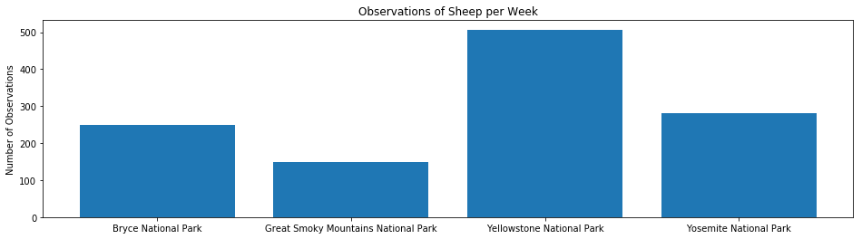

```python
plt.figure(figsize=(16, 4))
ax = plt.subplot()
plt.bar(range(len(obs_by_park)),
        obs_by_park.observations.values)
ax.set_xticks(range(len(obs_by_park)))
ax.set_xticklabels(obs_by_park.park_name.values)
plt.ylabel('Number of Observations')
plt.title('Observations of Sheep per Week')
plt.show()
```

# Foot and Mouth Reduction Effort

Park Rangers at Yellowstone National Park have been running a program to reduce the rate of foot and mouth disease at that park. The scientists want to test whether or not this program is working. They want to be able to detect reductions of at least 5 percentage points. For instance, if 10% of sheep in Yellowstone have foot and mouth disease, they’d like to be able to know this, with confidence

The only information that the scientists currently have is that last year it was recorded that 15% of sheep at Bryce National Park have foot and mouth disease

```python
baseline = 15

minimum_detectable_effect = 100*5./15

sample_size_per_variant = 870

yellowstone_weeks_observing = sample_size_per_variant/507.

bryce_weeks_observing = sample_size_per_variant/250.

print(bryce_weeks_observing)
```

```
3.48
```

# **Congratulations! THE END****